# ParkisonDiseasePrediction

```python
# Imports

import numpy as np
import pandas as pd
```

```python
# Read Data

df = pd.read_csv('parkinsons.data')
print("Number of Instances: {} , Number of Features: {}\n".format(df.shape[0], df.shape[1]))
df.head()
```

```
Number of Instances: 195 , Number of Features: 24
```

|  | name | MDVP:Fo(Hz) | MDVP:Fhi(Hz) | MDVP:Flo(Hz) | MDVP:Jitter(%) | MDVP:Jitter(Abs) | MDVP:RAP | MDVP:PPQ | Jitter:DDP | MDVP:Shimmer | ... | Shimmer:DDA | NHR | HNR | status | RPDE | DFA | spread1 | spread2 | D2 | PPE |
| --- | --- | --- | --- | --- | --- | --- | --- | --- | --- | --- | --- | --- | --- | --- | --- | --- | --- | --- | --- | --- | --- |
| 0 | phon_R01_S01_1 | 119.992 | 157.302 | 74.997 | 0.00784 | 0.00007 | 0.00370 | 0.00554 | 0.01109 | 0.04374 | ... | 0.06545 | 0.02211 | 21.033 | 1 | 0.414783 | 0.815285 | -4.813031 | 0.266482 | 2.301442 | 0.284654 |
| 1 | phon_R01_S01_2 | 122.400 | 148.650 | 113.819 | 0.00968 | 0.00008 | 0.00465 | 0.00696 | 0.01394 | 0.06134 | ... | 0.09403 | 0.01929 | 19.085 | 1 | 0.458359 | 0.819521 | -4.075192 | 0.335590 | 2.486855 | 0.368674 |
| 2 | phon_R01_S01_3 | 116.682 | 131.111 | 111.555 | 0.01050 | 0.00009 | 0.00544 | 0.00781 | 0.01633 | 0.05233 | ... | 0.08270 | 0.01309 | 20.651 | 1 | 0.429895 | 0.825288 | -4.443179 | 0.311173 | 2.342259 | 0.332634 |
| 3 | phon_R01_S01_4 | 116.676 | 137.871 | 111.366 | 0.00997 | 0.00009 | 0.00502 | 0.00698 | 0.01505 | 0.05492 | ... | 0.08771 | 0.01353 | 20.644 | 1 | 0.434969 | 0.819235 | -4.117501 | 0.334147 | 2.405554 | 0.368975 |
| 4 | phon_R01_S01_5 | 116.014 | 141.781 | 110.655 | 0.01284 | 0.00011 | 0.00655 | 0.00908 | 0.01966 | 0.06425 | ... | 0.10470 | 0.01767 | 19.649 | 1 | 0.417356 | 0.823484 | -3.747787 | 0.234513 | 2.332180 | 0.410335 |

5 rows × 24 columns

```python
# Get the features and labels data
X = df.loc[:,df.columns != 'status'].values[:,1:]
Y = df.loc[:,'status'].values
```

```python
from sklearn.preprocessing import MinMaxScaler

# Scaling features for later viewing
scaler = MinMaxScaler()
X = scaler.fit_transform(X)
```

```python
from sklearn.decomposition import PCA

# PCA Projection to 2D. Trying to understand if there is a pattern in behavior
pca = PCA(n_components = 2)
principalComponents = pca.fit_transform(X)

principalComponents = pd.DataFrame(data = principalComponents)
```

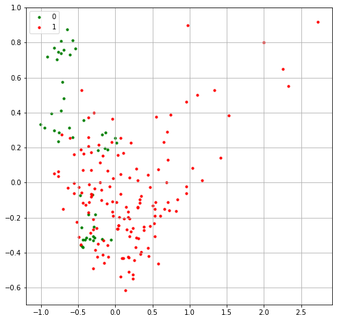

```python
import matplotlib.pyplot as plt
#%matplotlib qt
%matplotlib inline

# Trying to understand data through visualization

fig = plt.figure(figsize=(8,8))
ax = fig.add_subplot(111)

targets = [0,1]
colors = ['g', 'r']

for target, color in zip(targets,colors):
    indices = [index for index, value in enumerate(Y) if value == target]
    ax.scatter(principalComponents.loc[indices, 0], principalComponents.loc[indices, 1], c = color, s = 10)

ax.legend(targets)
ax.grid()
```

```python
# Split data into training, cross-validation and test data
# 60% for training, 20% for cross-validation and 20% for test

from sklearn.model_selection import train_test_split

train_data, evaluation_data, train_label, evaluation_label = train_test_split(X, Y, test_size = 0.4, random_state = 7)

cv_data, test_data, cv_label,test_label = train_test_split(evaluation_data, evaluation_label, test_size = 0.5, random_state = 4)

print("Shape:\n\n\
Train {}\n\
CV    {}\n\
Test  {}\n".format(train_data.shape, cv_data.shape, test_data.shape))
```

```
Shape:

Train (117, 22)
CV    (39, 22)
Test  (39, 22)
```

```python
from sklearn.linear_model import LogisticRegression
from sklearn.metrics import accuracy_score

logisticRegr = LogisticRegression(solver='liblinear', random_state=0)
logisticRegr.fit(train_data, train_label)

print("Score for train data           : {:.2f}%".format(logisticRegr.score(train_data,train_label)*100))
print("Score for cross-validation data: {:.2f}%".format(logisticRegr.score(cv_data, cv_label     )*100))
print("Score for test data            : {:.2f}%".format(logisticRegr.score(test_data, test_label )*100))
```

```
Score for train data           : 85.47%
Score for cross-validation data: 84.62%
Score for test data            : 76.92%
```

The model shows no signs of underfitting or overfitting

The accuracy of the model is 84.62% in the cross-validation data and 76.92% in the test data, but this is a case where accuracy may not be the best metric to evaluate the model. So, let’s take a look at the other evaluation metrics.

```python
# Model Evaluation metrics
from sklearn.metrics import accuracy_score, recall_score, precision_score, f1_score, confusion_matrix

predicted = logisticRegr.predict(cv_data)

print('Accuracy Score  : ' + str( accuracy_score(cv_label,predicted)))
print('Precision Score : ' + str(precision_score(cv_label,predicted)))
print('Recall Score    : ' + str(   recall_score(cv_label,predicted)))
print('F1 Score        : ' + str(       f1_score(cv_label,predicted)))

import matplotlib.pyplot as plt
import seaborn as sn

confusion_matrix = pd.crosstab(cv_label, predicted, rownames=['Actual'], colnames=['Predicted'])
sn.heatmap(confusion_matrix, annot=True)
plt.show()
```

[output not shown]

```
Accuracy Score  : 0.8461538461538461
Precision Score : 0.9032258064516129
Recall Score    : 0.9032258064516129
F1 Score        : 0.9032258064516129
```

Looking at the instances classified incorrectly, we can see that **3 cases were classified incorrectly as people not having Parkinson's (false negatives)**. And, 3 cases were incorrectly classified as having Parkison (false positive).

A false negative is more serious as a disease has been ignored, **which can lead to the death of the patient**. At the same time, a false positive would lead to an **unnecessary treatment - incurring additional cost**.

One thing that can be useful in this case is an error analysis. We can try categorize the situations where the hypothesis makes incorrect predictions. One hypothesis would be to add more training data to cover this situation or add features that cover this situation. However, this dataset is from the Internet, there is no direct way to change the dataset.

Therefore, an alternative is try to minimize the false negatives by using **Grid Search** to find the optimal parameters. Grid search can be used to improve any specific evaluation metric. Grid search builds a model for every combination of hyperparameters specified and evaluates each model.

```python
from sklearn.model_selection import GridSearchCV

grid_values = {'penalty'        : ['l1', 'l2'],
                'C'             : [0.001,.009,0.01,.09,1,5,10,25, 50, 100]
              }


gs_cls = GridSearchCV(logisticRegr, param_grid = grid_values,scoring = 'f1')
gs_cls.fit(train_data, train_label)

#Predict values based on new parameters
gs_predicted = gs_cls.predict(cv_data)

# New Model Evaluation metrics
print('Accuracy Score  : ' + str( accuracy_score(cv_label,gs_predicted)))
print('Precision Score : ' + str(precision_score(cv_label,gs_predicted)))
print('Recall Score    : ' + str(   recall_score(cv_label,gs_predicted)))
print('F1 Score        : ' + str(       f1_score(cv_label,gs_predicted)))

#Logistic Regression (Grid Search) Confusion matrix
confusion_matrix = pd.crosstab(cv_label, gs_predicted, rownames=['Actual'], colnames=['Predicted'])
sn.heatmap(confusion_matrix, annot=True)
plt.show()
```

[output not shown]

```
Accuracy Score  : 0.8461538461538461
Precision Score : 0.9032258064516129
Recall Score    : 0.9032258064516129
F1 Score        : 0.9032258064516129
```

If **F1 Score** is used as a parameter to be improved, seeking to eliminate the ignored Parkison patients and eliminate the costs of unnecessary treatments, it does not show any difference in relation to the hyper parameters used by Logistic Regression.

```python
from sklearn.model_selection import RandomizedSearchCV

grid_values = {'penalty'        : ['l1', 'l2'],
                'C'             : [0.001,.009,0.01,.09,1,5,10,25, 50, 100]
              }


gs_cls = GridSearchCV(logisticRegr, param_grid = grid_values,scoring = 'f1')
gs_cls.fit(train_data, train_label)

#Predict values based on new parameters
gs_predicted = gs_cls.predict(cv_data)

# New Model Evaluation metrics
print('Accuracy Score  : ' + str( accuracy_score(cv_label,gs_predicted)))
print('Precision Score : ' + str(precision_score(cv_label,gs_predicted)))
print('Recall Score    : ' + str(   recall_score(cv_label,gs_predicted)))
print('F1 Score        : ' + str(       f1_score(cv_label,gs_predicted)))

#Logistic Regression (Grid Search) Confusion matrix
confusion_matrix = pd.crosstab(cv_label, gs_predicted, rownames=['Actual'], colnames=['Predicted'])
sn.heatmap(confusion_matrix, annot=True)
plt.show()
```

[output not shown]

```
Accuracy Score  : 0.8461538461538461
Precision Score : 0.9032258064516129
Recall Score    : 0.9032258064516129
F1 Score        : 0.9032258064516129
```